# 16-29 2021

Sam

2025-07-21

## Předpisy celkem

Existuje viditelný nárust celkového úhnru předpisů v čase se zvýšenou mírou nárustu po a během COVIDu.

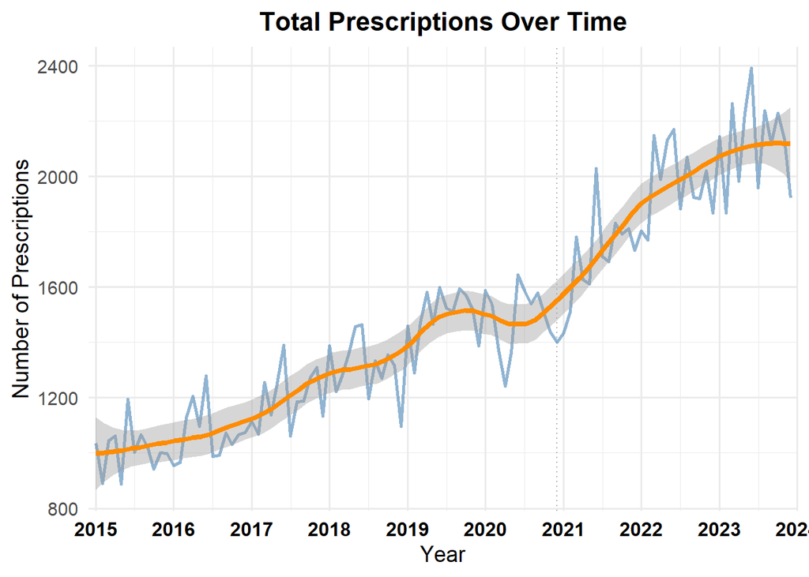

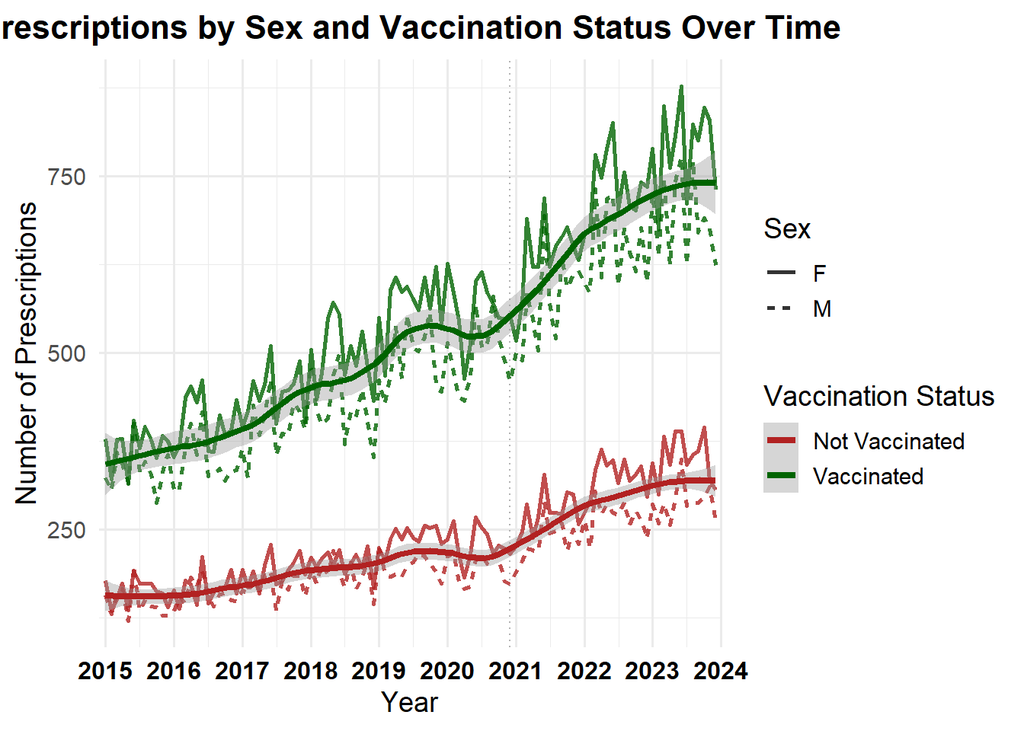

## Prvopředpisy

Prvopředpisy celkem mají viditelný rozdíl v porovnání před-covidového a po-covidového období. Tento nárůst ale může být vysvětlen jen stárnutím populace.

```
##
##  Welch Two Sample t-test
##
## data:  rate by period_group
## t = 5.6763, df = 45.999, p-value = 8.828e-07
## alternative hypothesis: true difference in means between group Post-COVID and group Pre-COVID is not equal to 0
## 95 percent confidence interval:
##  0.0002287661 0.0004801655
## sample estimates:
## mean in group Post-COVID  mean in group Pre-COVID
##              0.002226359              0.001871893
```

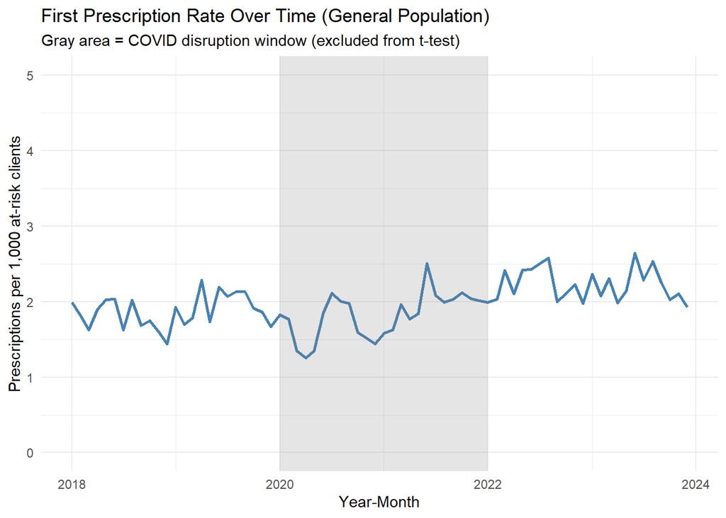

Rozdíl mezi prvopředpisovostí očkovaných a neočkovaných je naprosto minimální.

```
## # A tibble: 2 × 4
##   vacc_status        p_value mean_before mean_after
##   <chr>                <dbl>       <dbl>      <dbl>
## 1 Non-vaccinated 0.000149        0.00172    0.00204
## 2 Vaccinated     0.000000855     0.00195    0.00232
```

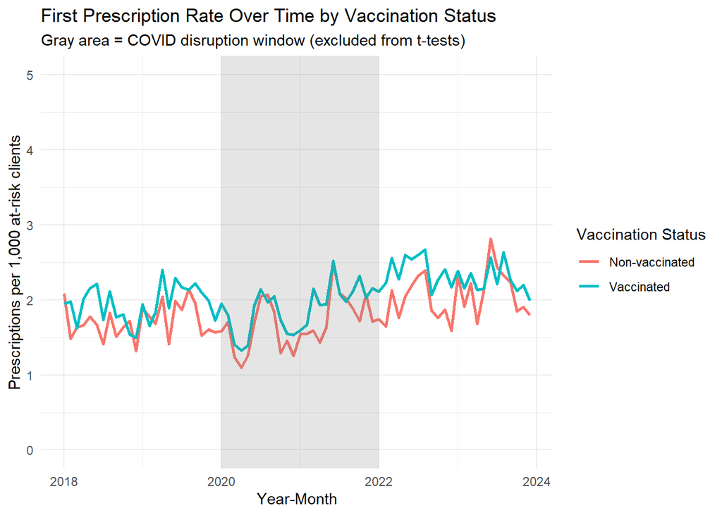

A není statisticky významný (p = 0,41)

```
##
## Call:
## lm(formula = rate ~ vaccinated * post_covid, data = monthly_rates)
##
## Residuals:
##        Min         1Q     Median         3Q        Max
## -4.723e-04 -1.994e-04 -8.287e-05  1.801e-04  1.531e-03
##
## Coefficients:
##                        Estimate Std. Error t value Pr(>|t|)
## (Intercept)           1.777e-03  4.086e-05  43.500  < 2e-16 ***
## vaccinated            1.923e-04  5.779e-05   3.328 0.001082 **
## post_covid            2.610e-04  7.644e-05   3.414 0.000806 ***
## vaccinated:post_covid 8.869e-05  1.081e-04   0.820 0.413203
## ---
## Signif. codes:  0 '***' 0.001 '**' 0.01 '*' 0.05 '.' 0.1 ' ' 1
##
## Residual standard error: 0.0003165 on 164 degrees of freedom
## Multiple R-squared:  0.2423, Adjusted R-squared:  0.2284
## F-statistic: 17.48 on 3 and 164 DF,  p-value: 6.785e-10
```

## Dá se nárůst všech předpisů vysvětlit pouze stoupající mírou prvopředpisovosti nebo je na vině multipředpisovost?

Počet unikátních klientů stále roste. To nemusí být nutně alarmující, pokud je míra multipředpisovosti stále stejná a do dalších let “zůstává” stále stejné relativní množství klientů.

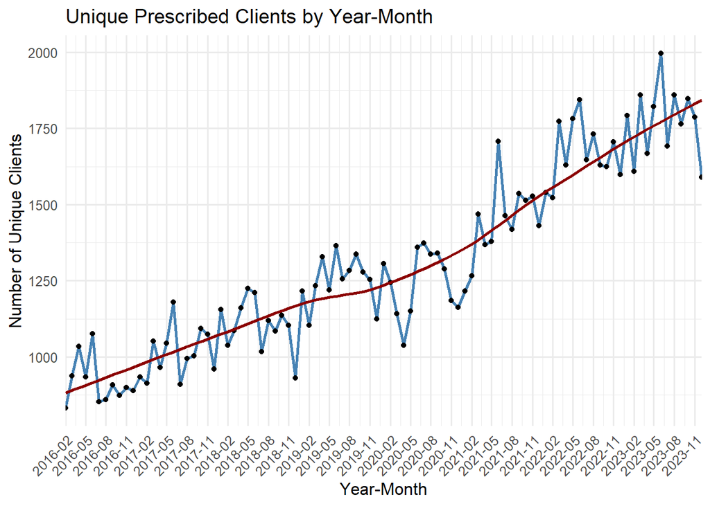

Podíl prvopředpisů v čase neustále klesá

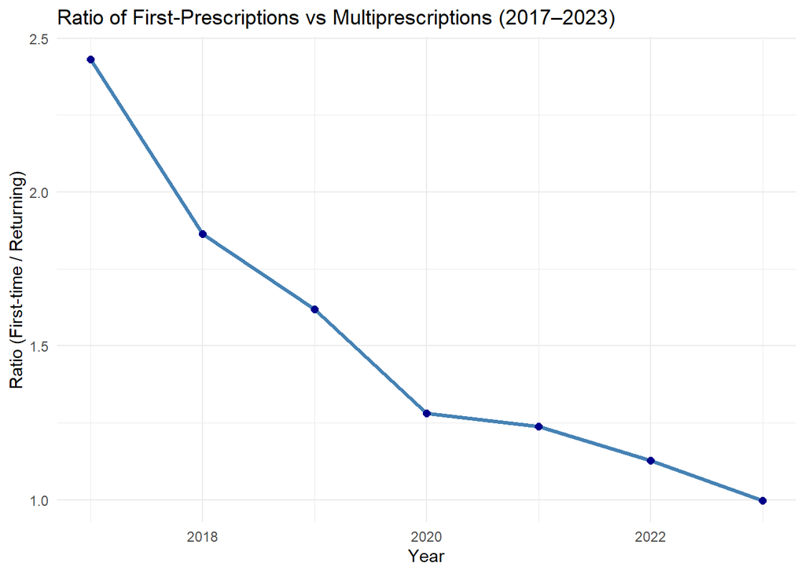

Míra “udržení” klienta v čase kolísá. Dá se ale všeobecně říct, že 11-15 % klientů neskončí na prvním předpisu.

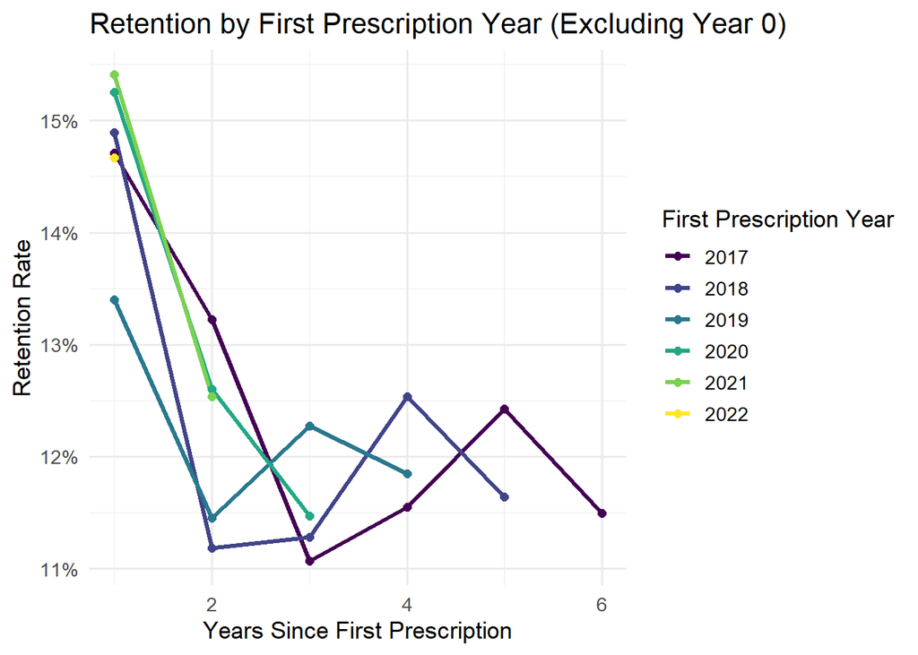

Doba mezi prvním a druhým předpisem se v čase snižuje. Pro roky 2020, 2021 a 2022 statisticky významně

```
## Call:
## coxph(formula = Surv(time, event) ~ first_presc_year, data = surv_data)
##
##   n= 32270, number of events= 8416
##
##                          coef exp(coef) se(coef)      z Pr(>|z|)
## first_presc_year2018 -0.04000   0.96079  0.03940 -1.015 0.310047
## first_presc_year2019  0.06033   1.06219  0.03806  1.585 0.112884
## first_presc_year2020  0.14865   1.16027  0.03896  3.816 0.000136 ***
## first_presc_year2021  0.13211   1.14124  0.03778  3.497 0.000470 ***
## first_presc_year2022  0.10752   1.11351  0.03706  2.901 0.003714 **
## ---
## Signif. codes:  0 '***' 0.001 '**' 0.01 '*' 0.05 '.' 0.1 ' ' 1
##
##                      exp(coef) exp(-coef) lower .95 upper .95
## first_presc_year2018    0.9608     1.0408    0.8894     1.038
## first_presc_year2019    1.0622     0.9414    0.9858     1.144
## first_presc_year2020    1.1603     0.8619    1.0750     1.252
## first_presc_year2021    1.1412     0.8762    1.0598     1.229
## first_presc_year2022    1.1135     0.8981    1.0355     1.197
##
## Concordance= 0.519  (se = 0.003 )
## Likelihood ratio test= 38.2  on 5 df,   p=3e-07
## Wald test            = 37.83  on 5 df,   p=4e-07
## Score (logrank) test = 37.89  on 5 df,   p=4e-07
```

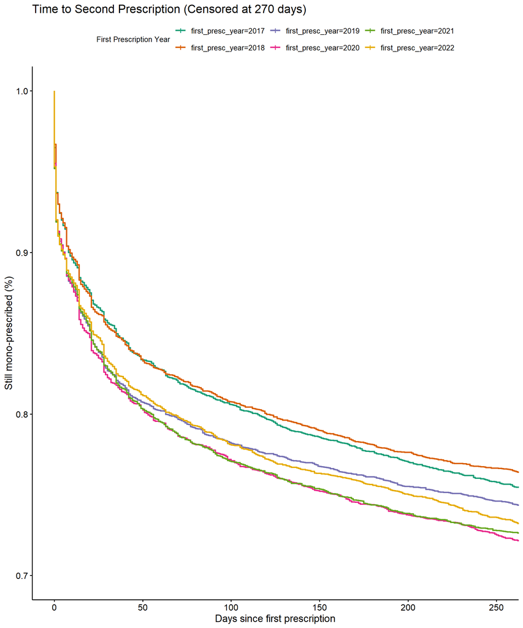

```r
fit <- survfit(Surv(time, event) ~ first_presc_year, data = surv_data)

ggsurvplot(
  fit,
  data = surv_data,
  conf.int = FALSE,
  risk.table = FALSE,
  pval = TRUE,
  legend.title = "First Prescription Year",
  xlab = "Days since first prescription",
  ylab = "Still mono-prescribed (%)",
  title = "Time to Second Prescription (Censored at 270 days)",
  palette = "Dark2",
  ylim = c(0.7, 1)
)
```

Počet předpisů multipředpisovnaých klientů za rok

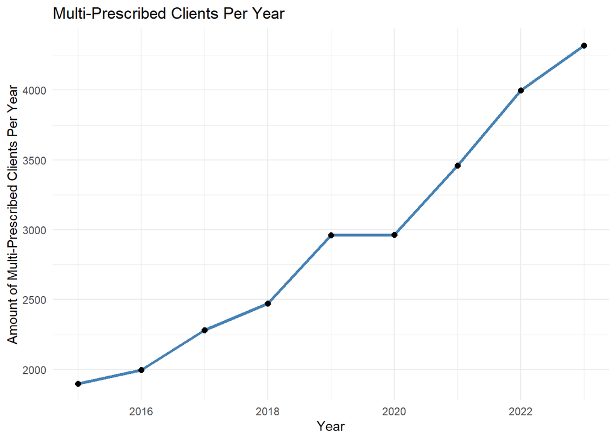

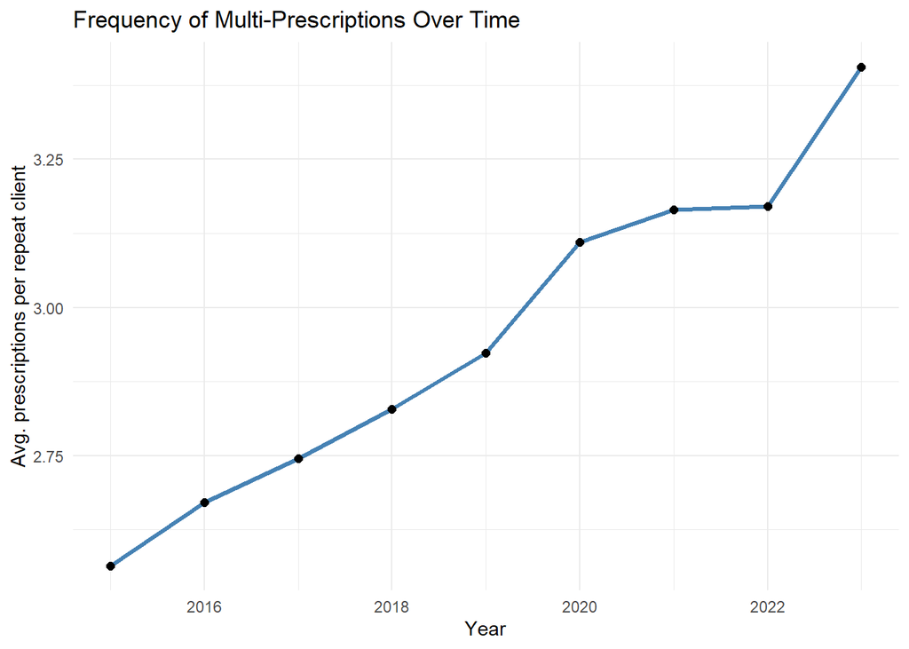

Roční míra multipředpisovosti - Počítáno vždy pro daný rok - tj. kolik předpisovaných lidí v daném roce bylo multipředpisovaných na 1000 předpisovaných

Výsledek není statisticky významný

```
## # A tibble: 2 × 4
##   vacc_status    p_value mean_before mean_after
##   <chr>            <dbl>       <dbl>      <dbl>
## 1 Non-vaccinated  0.0394        319.       375.
## 2 Vaccinated      0.122         316.       359.
```

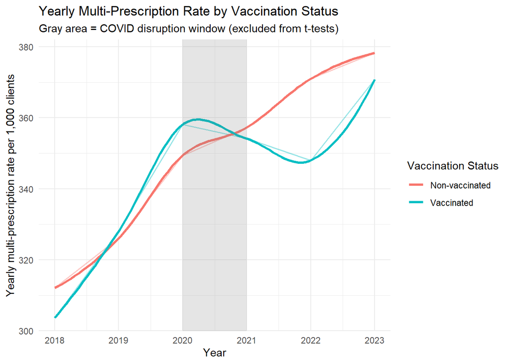

```
##
## Call:
## lm(formula = multi_rate ~ vaccinated * post_covid, data = did_data)
##
## Residuals:
##       1       2       3       4       5       6       7       8
##  -6.994 -12.230   6.994  12.230  -3.639 -11.423   3.639  11.423
##
## Coefficients:
##                       Estimate Std. Error t value Pr(>|t|)
## (Intercept)            319.053      9.249  34.494 4.21e-06 ***
## vaccinated              -3.205     13.081  -0.245   0.8185
## post_covid              55.579     13.081   4.249   0.0132 *
## vaccinated:post_covid  -11.989     18.499  -0.648   0.5523
## ---
## Signif. codes:  0 '***' 0.001 '**' 0.01 '*' 0.05 '.' 0.1 ' ' 1
##
## Residual standard error: 13.08 on 4 degrees of freedom
## Multiple R-squared:  0.8829, Adjusted R-squared:  0.795
## F-statistic: 10.05 on 3 and 4 DF,  p-value: 0.0247
```

Měsíční míra multipředpisovosti. Statisticky významný rozdíl mezi očko a neočko.

```
## # A tibble: 2 × 4
##   vacc_status     p_value mean_before mean_after
##   <chr>             <dbl>       <dbl>      <dbl>
## 1 Non-vaccinated 0.000110        219.       246.
## 2 Vaccinated     0.114           230.       237.
```

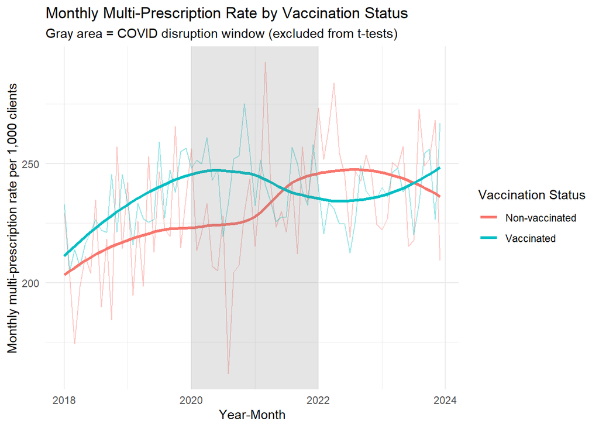

```
##
## Call:
## lm(formula = multi_rate ~ vaccinated * post_covid, data = did_data)
##
## Residuals:
##     Min      1Q  Median      3Q     Max
## -44.546 -11.907  -0.414  10.761  46.994
##
## Coefficients:
##                       Estimate Std. Error t value Pr(>|t|)
## (Intercept)            218.720      3.759  58.179  < 2e-16 ***
## vaccinated              11.384      5.317   2.141   0.0349 *
## post_covid              26.916      5.317   5.063 2.11e-06 ***
## vaccinated:post_covid  -20.419      7.519  -2.716   0.0079 **
## ---
## Signif. codes:  0 '***' 0.001 '**' 0.01 '*' 0.05 '.' 0.1 ' ' 1
##
## Residual standard error: 18.42 on 92 degrees of freedom
## Multiple R-squared:  0.2283, Adjusted R-squared:  0.2032
## F-statistic: 9.073 on 3 and 92 DF,  p-value: 2.533e-05
```

Kategorizace klientů na základě počtu předpisů v daném roce

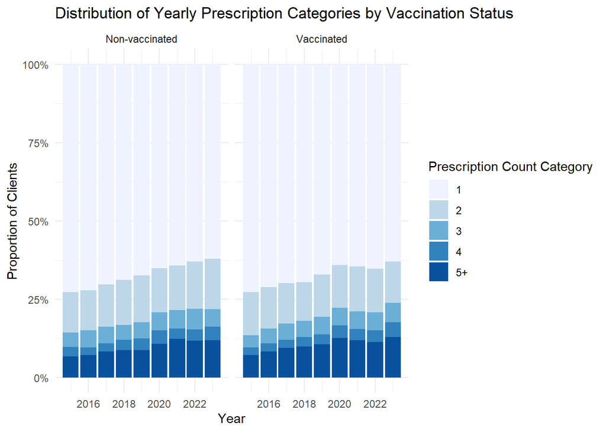

Intervaly mezi předpisy

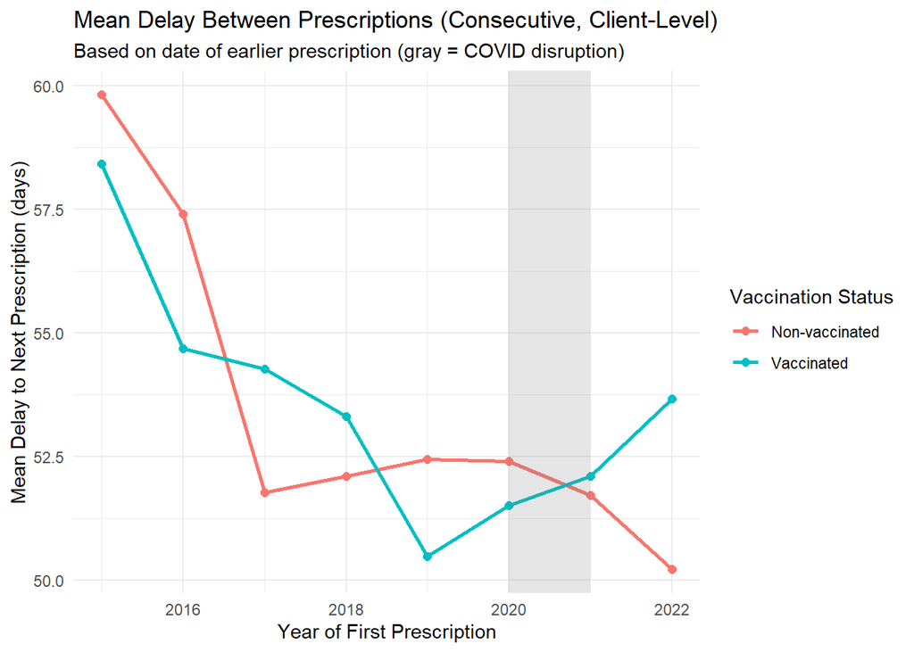

```
## # A tibble: 2 × 4
##   vacc_status     p_value mean_pre mean_post
##   <chr>             <dbl>    <dbl>     <dbl>
## 1 Non-vaccinated 0.000355     54.2      50.2
## 2 Vaccinated     0.907        53.8      53.7
```

```
##
## Call:
## lm(formula = delay_days ~ vaccinated * post_covid, data = did_model_data)
##
## Residuals:
##    Min     1Q Median     3Q    Max
## -54.23 -49.75 -25.75  19.25 313.79
##
## Coefficients:
##                       Estimate Std. Error t value Pr(>|t|)
## (Intercept)            54.2319     0.5981  90.680  < 2e-16 ***
## vaccinated             -0.4805     0.7087  -0.678 0.497752
## post_covid             -4.0231     1.1411  -3.526 0.000423 ***
## vaccinated:post_covid   3.9378     1.3606   2.894 0.003801 **
## ---
## Signif. codes:  0 '***' 0.001 '**' 0.01 '*' 0.05 '.' 0.1 ' ' 1
##
## Residual standard error: 72.12 on 68888 degrees of freedom
## Multiple R-squared:  0.000195,   Adjusted R-squared:  0.0001514
## F-statistic: 4.478 on 3 and 68888 DF,  p-value: 0.00379
```

# Největší vliv na celkový úhrn předpisů má multipředpisovost. V dlouhodobém horizontu na ni očkování vliv nemá a nebo ho má jen minimální.

### Krátkodobý vliv SCCS. Skupina 16-29 bohužel nemá dostatek dat pro statisticky významnou evaluaci. Rozšířeno na 16-39

# Prvopředpisy

```
## Call:
## coxph(formula = Surv(rep(1, 6512L), event) ~ exposure_start_day +
##     strata(indivL) + offset(log(interval)), data = chopdat, method = "exact")
##
##   n= 6512, number of events= 814
##
##                       coef exp(coef) se(coef)     z Pr(>|z|)
## exposure_start_day1 0.4193    1.5208   0.2245 1.868  0.06182 .
## exposure_start_day2 0.4658    1.5933   0.2196 2.121  0.03393 *
## exposure_start_day3 0.1316    1.1406   0.1748 0.753  0.45162
## exposure_start_day4 0.1390    1.1491   0.1794 0.774  0.43864
## exposure_start_day5 0.3015    1.3519   0.1054 2.860  0.00424 **
## exposure_start_day6 0.2235    1.2505   0.1086 2.059  0.03952 *
## exposure_start_day7 0.1499    1.1617   0.1089 1.376  0.16877
## ---
## Signif. codes:  0 '***' 0.001 '**' 0.01 '*' 0.05 '.' 0.1 ' ' 1
##
##                     exp(coef) exp(-coef) lower .95 upper .95
## exposure_start_day1     1.521     0.6575    0.9795     2.361
## exposure_start_day2     1.593     0.6276    1.0360     2.450
## exposure_start_day3     1.141     0.8767    0.8098     1.607
## exposure_start_day4     1.149     0.8703    0.8084     1.633
## exposure_start_day5     1.352     0.7397    1.0995     1.662
## exposure_start_day6     1.250     0.7997    1.0108     1.547
## exposure_start_day7     1.162     0.8608    0.9384     1.438
##
## Concordance= 0.778  (se = 0.011 )
## Likelihood ratio test= 14.44  on 7 df,   p=0.04
## Wald test            = 14.87  on 7 df,   p=0.04
## Score (logrank) test = 14.99  on 7 df,   p=0.04
```

```
## Call:
## coxph(formula = Surv(rep(1, 23944L), event) ~ exposure_start_day +
##     strata(indivL) + offset(log(interval)), data = chopdat, method = "exact")
##
##   n= 23944, number of events= 2993
##
##                        coef exp(coef) se(coef)     z Pr(>|z|)
## exposure_start_day1 0.23970   1.27087  0.12419 1.930 0.053592 .
## exposure_start_day2 0.41464   1.51382  0.11429 3.628 0.000286 ***
## exposure_start_day3 0.24976   1.28371  0.08418 2.967 0.003008 **
## exposure_start_day4 0.13325   1.14253  0.09138 1.458 0.144797
## exposure_start_day5 0.09433   1.09892  0.05799 1.627 0.103776
## exposure_start_day6 0.05659   1.05822  0.05886 0.962 0.336290
## exposure_start_day7 0.13277   1.14199  0.05571 2.383 0.017159 *
## ---
## Signif. codes:  0 '***' 0.001 '**' 0.01 '*' 0.05 '.' 0.1 ' ' 1
##
##                     exp(coef) exp(-coef) lower .95 upper .95
## exposure_start_day1     1.271     0.7869    0.9963     1.621
## exposure_start_day2     1.514     0.6606    1.2100     1.894
## exposure_start_day3     1.284     0.7790    1.0885     1.514
## exposure_start_day4     1.143     0.8752    0.9552     1.367
## exposure_start_day5     1.099     0.9100    0.9809     1.231
## exposure_start_day6     1.058     0.9450    0.9429     1.188
## exposure_start_day7     1.142     0.8757    1.0239     1.274
##
## Concordance= 0.785  (se = 0.006 )
## Likelihood ratio test= 24.65  on 7 df,   p=9e-04
## Wald test            = 25.93  on 7 df,   p=5e-04
## Score (logrank) test = 26.1  on 7 df,   p=5e-04
```

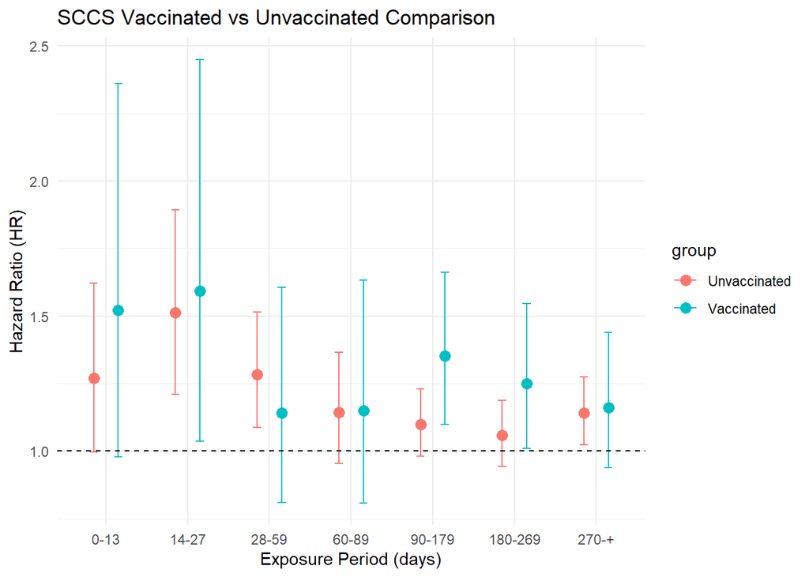

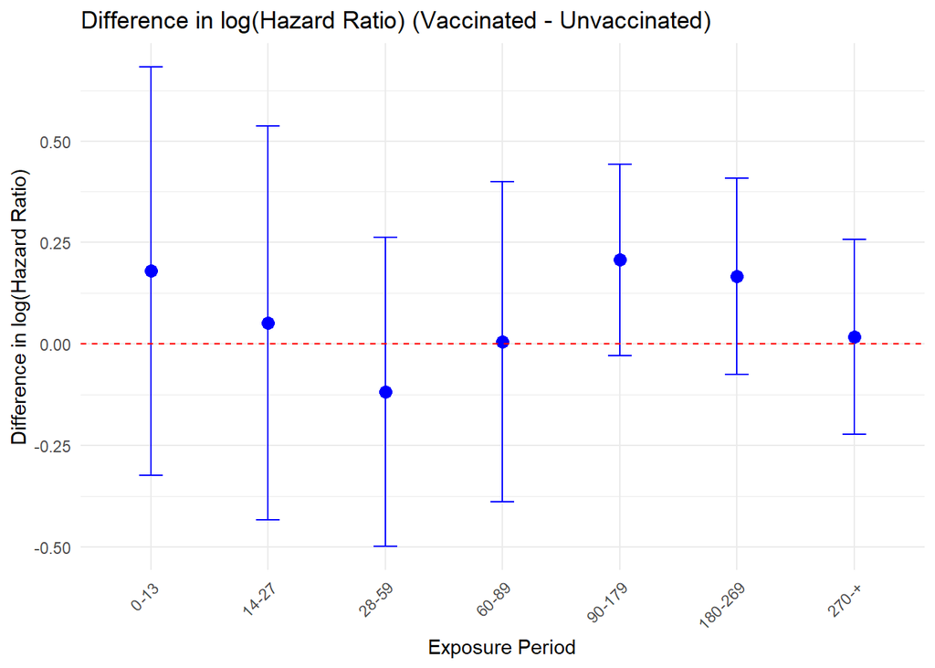

# Předpisy celkem

```
## Call:
## coxph(formula = Surv(rep(1, 68848L), event) ~ exposure_start_day +
##     strata(indivL) + offset(log(interval)), data = chopdat, method = "exact")
##
##   n= 68848, number of events= 8606
##
##                         coef exp(coef) se(coef)      z Pr(>|z|)
## exposure_start_day1  0.26637   1.30522  0.07282  3.658 0.000254 ***
## exposure_start_day2 -0.01795   0.98221  0.08345 -0.215 0.829699
## exposure_start_day3 -0.02257   0.97768  0.05659 -0.399 0.689972
## exposure_start_day4  0.01202   1.01209  0.05738  0.210 0.834045
## exposure_start_day5  0.15964   1.17309  0.03357  4.755 1.98e-06 ***
## exposure_start_day6  0.12766   1.13617  0.03399  3.756 0.000173 ***
## exposure_start_day7  0.28555   1.33049  0.03123  9.143  < 2e-16 ***
## ---
## Signif. codes:  0 '***' 0.001 '**' 0.01 '*' 0.05 '.' 0.1 ' ' 1
##
##                     exp(coef) exp(-coef) lower .95 upper .95
## exposure_start_day1    1.3052     0.7662    1.1316     1.505
## exposure_start_day2    0.9822     1.0181    0.8340     1.157
## exposure_start_day3    0.9777     1.0228    0.8750     1.092
## exposure_start_day4    1.0121     0.9881    0.9044     1.133
## exposure_start_day5    1.1731     0.8525    1.0984     1.253
## exposure_start_day6    1.1362     0.8801    1.0629     1.214
## exposure_start_day7    1.3305     0.7516    1.2515     1.414
##
## Concordance= 0.797  (se = 0.003 )
## Likelihood ratio test= 103.3  on 7 df,   p=<2e-16
## Wald test            = 106.3  on 7 df,   p=<2e-16
## Score (logrank) test = 106.8  on 7 df,   p=<2e-16
```

```
## Call:
## coxph(formula = Surv(rep(1, 212920L), event) ~ exposure_start_day +
##     strata(indivL) + offset(log(interval)), data = chopdat, method = "exact")
##
##   n= 212920, number of events= 26615
##
##                        coef exp(coef) se(coef)      z Pr(>|z|)
## exposure_start_day1 0.17604   1.19249  0.04314  4.081 4.48e-05 ***
## exposure_start_day2 0.21101   1.23493  0.04242  4.974 6.55e-07 ***
## exposure_start_day3 0.07318   1.07592  0.03073  2.381   0.0172 *
## exposure_start_day4 0.05219   1.05358  0.03196  1.633   0.1024
## exposure_start_day5 0.14773   1.15920  0.01913  7.721 1.16e-14 ***
## exposure_start_day6 0.10705   1.11299  0.01944  5.507 3.66e-08 ***
## exposure_start_day7 0.23237   1.26158  0.01807 12.857  < 2e-16 ***
## ---
## Signif. codes:  0 '***' 0.001 '**' 0.01 '*' 0.05 '.' 0.1 ' ' 1
##
##                     exp(coef) exp(-coef) lower .95 upper .95
## exposure_start_day1     1.192     0.8386    1.0958     1.298
## exposure_start_day2     1.235     0.8098    1.1364     1.342
## exposure_start_day3     1.076     0.9294    1.0130     1.143
## exposure_start_day4     1.054     0.9491    0.9896     1.122
## exposure_start_day5     1.159     0.8627    1.1165     1.204
## exposure_start_day6     1.113     0.8985    1.0714     1.156
## exposure_start_day7     1.262     0.7927    1.2177     1.307
##
## Concordance= 0.793  (se = 0.002 )
## Likelihood ratio test= 204.4  on 7 df,   p=<2e-16
## Wald test            = 207.8  on 7 df,   p=<2e-16
## Score (logrank) test = 208.4  on 7 df,   p=<2e-16
```

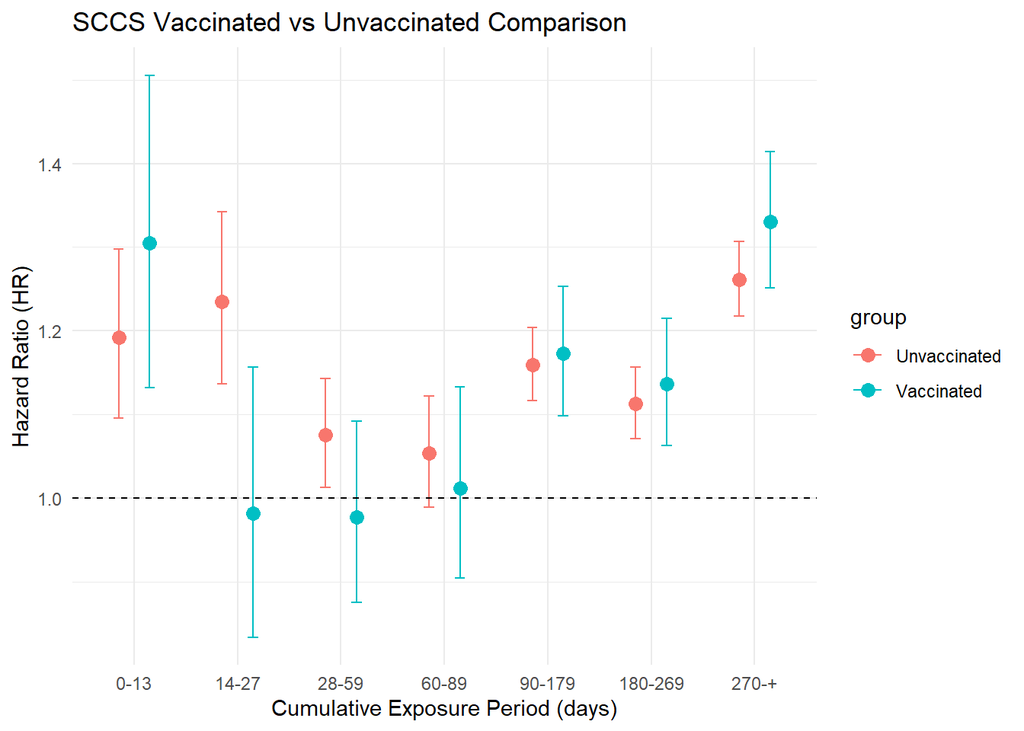

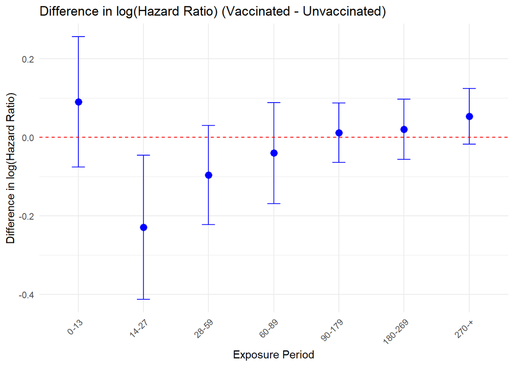

# Riziko je v zásadě srovnatelné

## Závěr: V populaci 16-29 (k roku 2021) dochází k výraznému nárustu předpisů v čase. Vysvětlením však může být samotné stárnutí populace. Prvopředpisovost mírně stoupá, ne však natolik, aby dokázala vysvětlit celkový nárůst. Ten je v první řadě způsoben multipředpisovostí. Vliv vakcinace na multipředpisovost je minimální.

## SCCS prvopředpisů a celkového počtu předpisů +- 1 rok od rozhodného data vykazuje drobné odchylky, ne však natolik velké, aby bylo možné jednoznačně prokázat vliv vakcinace na předpisovost.